# IE_582_PROJECT_Kerem_Tekeli_2022702066

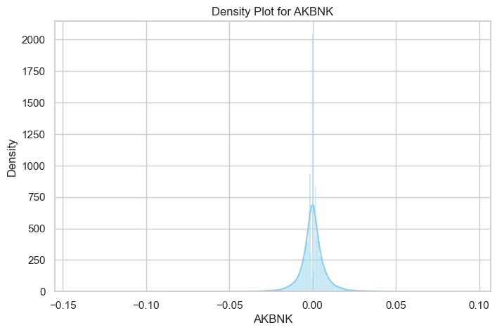

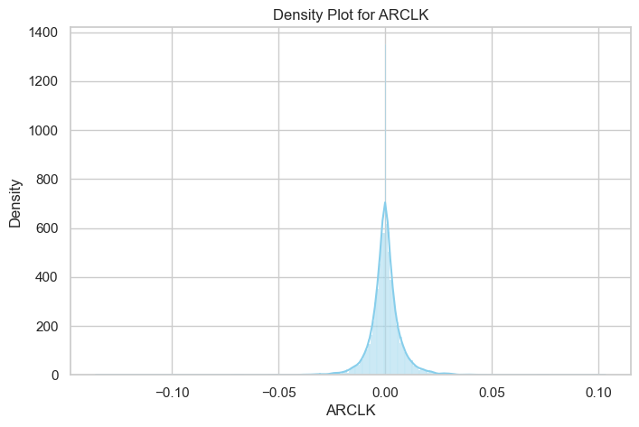

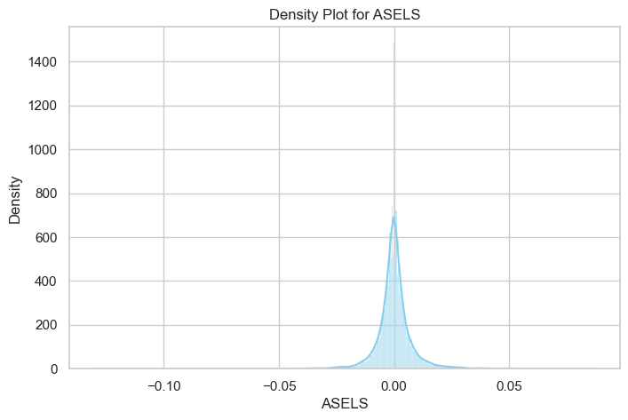

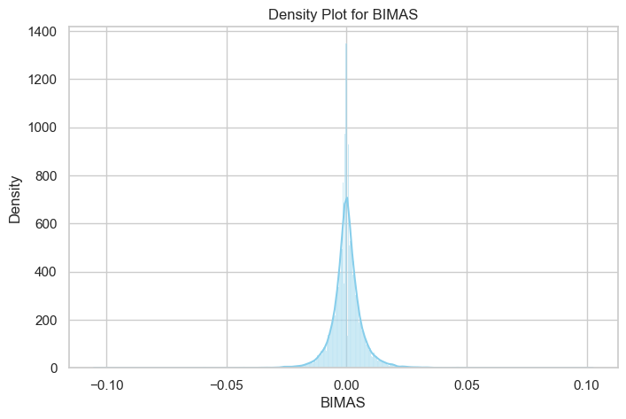

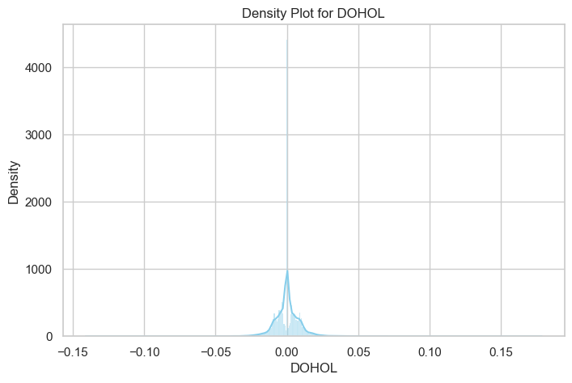

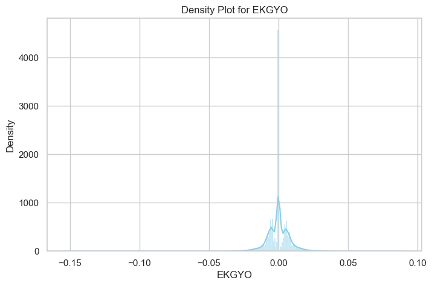

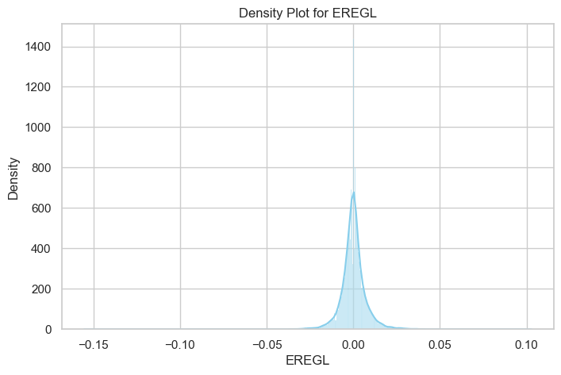

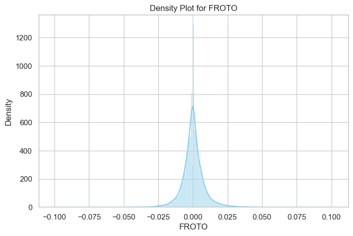

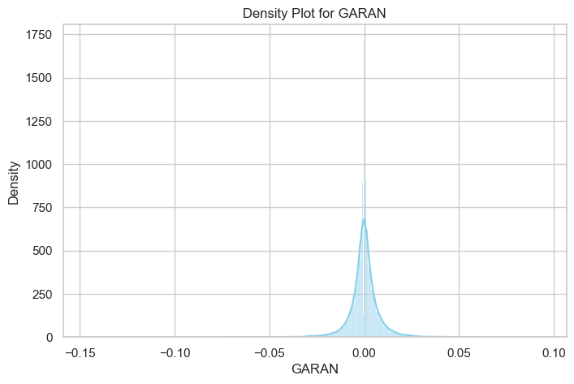

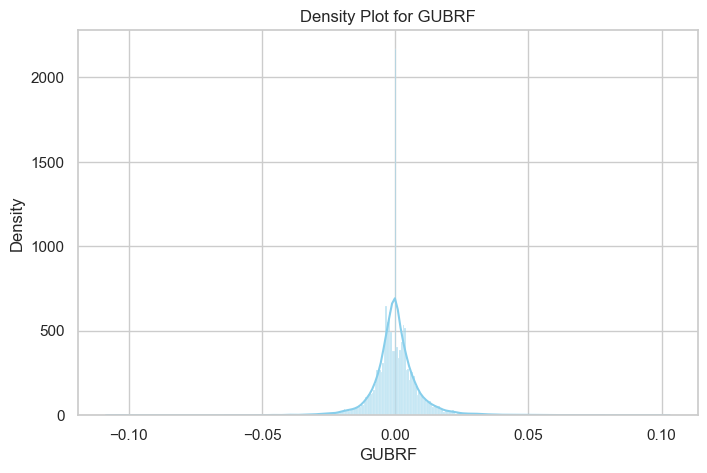

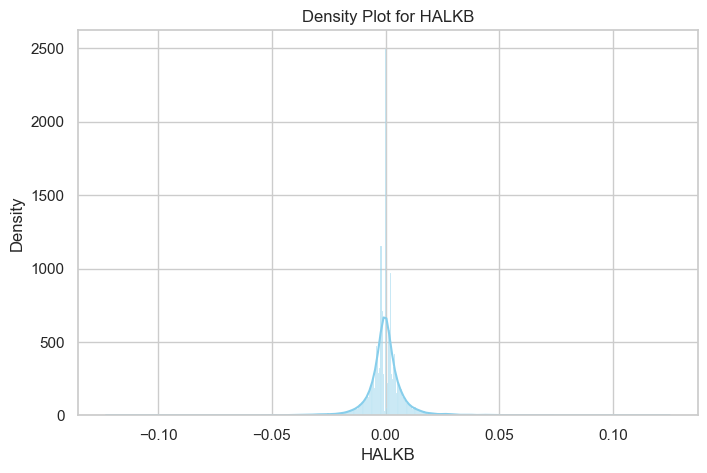

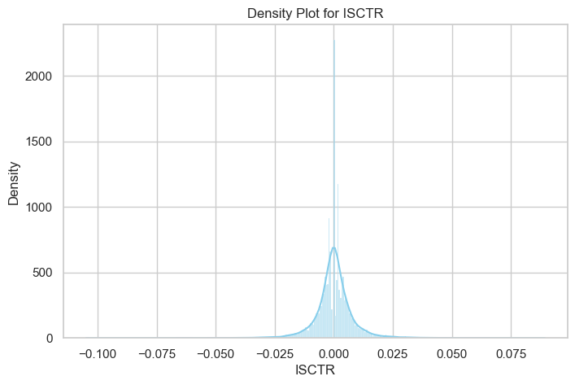

[18 more figures not shown]

```python
import pandas as pd
import seaborn as sns
import matplotlib.pyplot as plt

class DensityPlotter:
    def __init__(self, df):
        self.df = df

    def generate_density_plots(self):
        # Set the style for the plots
        sns.set(style="whitegrid")

        # Get the list of columns in the DataFrame
        columns = self.df.columns

        # Generate density plots for each column
        for col in columns:
            plt.figure(figsize=(8, 5))
            sns.histplot(self.df[col], kde=True, color='skyblue')
            plt.title(f'Density Plot for {col}')
            plt.xlabel(col)
            plt.ylabel('Density')
            plt.show()
plotter = DensityPlotter(log_df)
plotter.generate_density_plots()
```

Summary Statistics

```python
import pandas as pd

class TimeSeriesStatistics:
    def __init__(self, dataframe):
        self.dataframe = dataframe

    def calculate_descriptive_stats(self):
        return self.dataframe.describe()

    def calculate_mean(self):
        return self.dataframe.mean()

    def calculate_median(self):
        return self.dataframe.median()

    def calculate_std_dev(self):
        return self.dataframe.std()

    def calculate_min(self):
        return self.dataframe.min()

    def calculate_max(self):
        return self.dataframe.max()

    def calculate_quantiles(self, quantiles_list):
        return self.dataframe.quantile(quantiles_list)

    def calculate_range(self):
        return self.dataframe.max() - self.dataframe.min()

    def calculate_skewness(self):
        return self.dataframe.skew()

    def calculate_kurtosis(self):
        return self.dataframe.kurt()

    def print_all_statistics(self):
        print("Descriptive Statistics:")
        print(self.calculate_descriptive_stats())
        print("\nMean Values:")
        print(self.calculate_mean())
        print("\nMedian Values:")
        print(self.calculate_median())
        print("\nStandard Deviation:")
        print(self.calculate_std_dev())
        print("\nMinimum Values:")
        print(self.calculate_min())
        print("\nMaximum Values:")
        print(self.calculate_max())
        print("\nQuantiles:")
        print(self.calculate_quantiles([0.25, 0.5, 0.75]))
        print("\nRange:")
        print(self.calculate_range())
        print("\nSkewness:")
        print(self.calculate_skewness())
        print("\nKurtosis:")
        print(self.calculate_kurtosis())
stat=TimeSeriesStatistics(log_df)
stat.print_all_statistics()
```

```
Descriptive Statistics:
short_name         AKBNK         ARCLK         ASELS         BIMAS  \
count       15006.000000  15006.000000  15006.000000  15006.000000
mean            0.000118      0.000130      0.000118      0.000155
std             0.008491      0.007794      0.008167      0.006997
min            -0.142875     -0.135772     -0.130194     -0.105173
25%            -0.003151     -0.002986     -0.002794     -0.002736
50%             0.000000      0.000000      0.000000      0.000000
75%             0.003380      0.003017      0.002736      0.002907
max             0.094959      0.103267      0.087155      0.102558

short_name         DOHOL         EKGYO         EREGL         FROTO  \
count       15006.000000  15006.000000  15006.000000  15006.000000
mean            0.000189      0.000084      0.000133      0.000194
std             0.009495      0.009026      0.007833      0.008767
min            -0.140865     -0.154163     -0.155325     -0.101104
25%            -0.004030     -0.004647     -0.003069     -0.003457
50%             0.000000      0.000000      0.000000      0.000000
75%             0.004393      0.004685      0.002955      0.003518
max             0.178449      0.090761      0.102760      0.102205

short_name         GARAN         GUBRF  ...          SISE         TAVHL  \
count       15006.000000  15006.000000  ...  15006.000000  15006.000000
mean            0.000131      0.000234  ...      0.000164      0.000123
std             0.008574      0.010366  ...      0.007822      0.009178
min            -0.146643     -0.108555  ...     -0.136430     -0.223147
25%            -0.002956     -0.003559  ...     -0.002920     -0.003604
50%             0.000000      0.000000  ...      0.000000      0.000000
75%             0.003047      0.003630  ...      0.003109      0.003580
max             0.094628      0.103016  ...      0.094673      0.207571

short_name         TCELL         THYAO         TKFEN         TTKOM  \
count       15006.000000  15006.000000  15006.000000  15006.000000
mean            0.000108      0.000183      0.000072      0.000112
std             0.007786      0.008331      0.008788      0.008793
min            -0.104379     -0.165185     -0.209236     -0.159165
25%            -0.003056     -0.003013     -0.003299     -0.003298
50%             0.000000      0.000000      0.000000      0.000000
75%             0.003151      0.003080      0.003356      0.003420
max             0.092863      0.088947      0.126436      0.111896
```

[output cut: 292 more lines]

```
PETKM    16.302827
PGSUS    33.959470
SAHOL    16.203219
SASA     32.023010
SISE     24.992040
TAVHL    56.230531
TCELL    14.732887
THYAO    22.982247
TKFEN    36.205054
TTKOM    21.037788
TUPRS    16.260412
VAKBN    19.328792
VESTL    14.532886
YKBNK    15.296839
dtype: float64
```

Test Normality using anderson-darling test

```python
import pandas as pd
import scipy.stats as stats

import pandas as pd
import scipy.stats as stats

class DistributionAnalyzer:
    def __init__(self, df):
        self.df = df

    def determine_distributions(self, significance_level=0.05):
        columns = self.df.columns
        distribution_results = {}
        for col in columns:
            result = self._perform_anderson_darling_test(self.df[col])
            is_normal = result.statistic < result.critical_values[2]  # 2 corresponds to the 95% confidence level
            # Store the results in the dictionary
            distribution_results[col] = {
                'Distribution': 'Normal' if is_normal else 'Non-Normal',
                'Anderson-Darling Statistic': result.statistic,
                'Critical Values': result.critical_values,
                'Significance Level': significance_level
            }

        return distribution_results

    def _perform_anderson_darling_test(self, data):
        result = stats.anderson(data)

        return result

analyzer = DistributionAnalyzer(log_df)
distribution_results = analyzer.determine_distributions()

for col, result in distribution_results.items():
    print(f"Column: {col}, Distribution: {result['Distribution']}")
    print(f"Anderson-Darling Statistic: {result['Anderson-Darling Statistic']:.4f}")
    print(f"Critical Values: {result['Critical Values']}")
    print(f"Significance Level: {result['Significance Level']}")
    print('-' * 50)
```

```
Column: AKBNK, Distribution: Non-Normal
Anderson-Darling Statistic: 472.6692
Critical Values: [0.576 0.656 0.787 0.918 1.092]
Significance Level: 0.05
--------------------------------------------------
Column: ARCLK, Distribution: Non-Normal
Anderson-Darling Statistic: 419.1374
Critical Values: [0.576 0.656 0.787 0.918 1.092]
Significance Level: 0.05
--------------------------------------------------
Column: ASELS, Distribution: Non-Normal
Anderson-Darling Statistic: 595.6172
Critical Values: [0.576 0.656 0.787 0.918 1.092]
Significance Level: 0.05
--------------------------------------------------
Column: BIMAS, Distribution: Non-Normal
Anderson-Darling Statistic: 396.7493
Critical Values: [0.576 0.656 0.787 0.918 1.092]
Significance Level: 0.05
--------------------------------------------------
Column: DOHOL, Distribution: Non-Normal
Anderson-Darling Statistic: 381.1747
Critical Values: [0.576 0.656 0.787 0.918 1.092]
Significance Level: 0.05
--------------------------------------------------
Column: EKGYO, Distribution: Non-Normal
Anderson-Darling Statistic: 367.5836
Critical Values: [0.576 0.656 0.787 0.918 1.092]
Significance Level: 0.05
--------------------------------------------------
Column: EREGL, Distribution: Non-Normal
Anderson-Darling Statistic: 431.6612
Critical Values: [0.576 0.656 0.787 0.918 1.092]
Significance Level: 0.05
--------------------------------------------------
Column: FROTO, Distribution: Non-Normal
Anderson-Darling Statistic: 396.7231
Critical Values: [0.576 0.656 0.787 0.918 1.092]
Significance Level: 0.05
--------------------------------------------------
```

[output cut: 95 more lines]

```
Column: VAKBN, Distribution: Non-Normal
Anderson-Darling Statistic: 519.8866
Critical Values: [0.576 0.656 0.787 0.918 1.092]
Significance Level: 0.05
--------------------------------------------------
Column: VESTL, Distribution: Non-Normal
Anderson-Darling Statistic: 544.3446
Critical Values: [0.576 0.656 0.787 0.918 1.092]
Significance Level: 0.05
--------------------------------------------------
Column: YKBNK, Distribution: Non-Normal
Anderson-Darling Statistic: 387.0467
Critical Values: [0.576 0.656 0.787 0.918 1.092]
Significance Level: 0.05
--------------------------------------------------
```

Check Stationarity of log returns(Augmented Dickey-fuller test was used.Every stock data log return is stationary)

```python
import pandas as pd
from statsmodels.tsa.stattools import adfuller

class UnitRootTester:
    def __init__(self, df):
        self.df = df

    def conduct_adf_test(self, significance_level=0.05):
        results = {}

        for col in self.df.columns:
            result = self._perform_adf_test(self.df[col])
            results[col] = {
                'ADF Statistic': result[0],
                'p-value': result[1],
                'Critical Values': result[4],
                'Is Stationary': result[1] < significance_level
            }

        return results
    def _perform_adf_test(self, data):
        result = adfuller(data)
        return result
#Tester and Results
tester = UnitRootTester(log_df)
adf_results = tester.conduct_adf_test()
for col, result in adf_results.items():
    print(f"Column: {col}")
    print(f"ADF Statistic: {result['ADF Statistic']:.4f}")
    print(f"p-value: {result['p-value']:.4f}")
    print(f"Critical Values: {result['Critical Values']}")
    print(f"Is Stationary: {result['Is Stationary']}")
    print('-' * 50)
```

```
Column: AKBNK
ADF Statistic: -24.7040
p-value: 0.0000
Critical Values: {'1%': -3.4307864936342365, '5%': -2.8617329112884686, '10%': -2.566872682025269}
Is Stationary: True
--------------------------------------------------
Column: ARCLK
ADF Statistic: -25.9046
p-value: 0.0000
Critical Values: {'1%': -3.43078646450054, '5%': -2.861732898413582, '10%': -2.5668726751721134}
Is Stationary: True
--------------------------------------------------
Column: ASELS
ADF Statistic: -17.6863
p-value: 0.0000
Critical Values: {'1%': -3.4307870771260105, '5%': -2.861733169147591, '10%': -2.566872819280753}
Is Stationary: True
--------------------------------------------------
Column: BIMAS
ADF Statistic: -29.9556
p-value: 0.0000
Critical Values: {'1%': -3.430786348004635, '5%': -2.8617328469312184, '10%': -2.5668726477686366}
Is Stationary: True
--------------------------------------------------
Column: DOHOL
ADF Statistic: -18.1438
p-value: 0.0000
Critical Values: {'1%': -3.430787018706643, '5%': -2.8617331433306625, '10%': -2.5668728055386945}
Is Stationary: True
--------------------------------------------------
Column: EKGYO
ADF Statistic: -17.0015
p-value: 0.0000
Critical Values: {'1%': -3.4307870479143747, '5%': -2.861733156238264, '10%': -2.5668728124092643}
Is Stationary: True
--------------------------------------------------
Column: EREGL
ADF Statistic: -23.5887
p-value: 0.0000
Critical Values: {'1%': -3.4307866393610773, '5%': -2.8617329756886876, '10%': -2.5668727163047738}
```

[output cut: 125 more lines]

```
Critical Values: {'1%': -3.430787018706643, '5%': -2.8617331433306625, '10%': -2.5668728055386945}
Is Stationary: True
--------------------------------------------------
Column: VESTL
ADF Statistic: -17.2603
p-value: 0.0000
Critical Values: {'1%': -3.4307871063415516, '5%': -2.861733182058644, '10%': -2.56687282615316}
Is Stationary: True
--------------------------------------------------
Column: YKBNK
ADF Statistic: -26.1294
p-value: 0.0000
Critical Values: {'1%': -3.43078646450054, '5%': -2.861732898413582, '10%': -2.5668726751721134}
Is Stationary: True
--------------------------------------------------
```

For all 30 stocks create y data(Hourly stock values for a given day as dataframe,it is stored in a list.)

```python
#Form the output data
class HourlyToDailyConverter:
    def __init__(self, stock_data):
        self.stock_data = stock_data
        self.daily_data_list = []

    def preprocess_data(self):
        # Extract date and hour columns
        self.stock_data['date'] = self.stock_data.index.date
        self.stock_data['hour_of_day'] = self.stock_data.index.hour
    def convert_to_daily(self):
        # Filter hours between 8:00 and 18:00
        filtered_data = self.stock_data[(self.stock_data['hour_of_day'] >= 9) & (self.stock_data['hour_of_day'] <= 18)]

        # Get the unique column names excluding date and hour_of_day
        column_names = [col for col in self.stock_data.columns if col not in ['date', 'hour_of_day']]

        # Loop through each column and convert to daily
        for column_name in column_names:
            # Pivot the DataFrame with proper aggregation for each column
            daily_data = filtered_data.pivot_table(
                index='date', columns='hour_of_day', values=column_name, aggfunc='mean'
            )

            daily_data.index=pd.to_datetime(daily_data.index)
            # Store the result in the list
            daily_data=daily_data.ffill()
            self.daily_data_list.append(pd.DataFrame(daily_data))
        return self.daily_data_list
    def display_daily_data(self):
        # Display the resulting DataFrames in the list
        for column_name, daily_data in self.daily_data_list:
            print(f"\nDaily Data for {column_name}:\n{daily_data}")
converter = HourlyToDailyConverter(log_df)
converter.preprocess_data()
#List containing 30 days were created
output_list=converter.convert_to_daily()
#An example element from the list is selected an displayed
output_list[5].tail()
```

| hour_of_day date | 9 | 10 | 11 | 12 | 13 | 14 | 15 | 16 | 17 | 18 |
| --- | --- | --- | --- | --- | --- | --- | --- | --- | --- | --- |
| 2024-01-05 | -0.001378 | 0.006873 | -0.005495 | 0.001376 | 0.001375 | 0.024425 | 0.005348 | 0.001332 | 0.011913 | 0.005249 |
| 2024-01-08 | 0.011711 | 0.006447 | 0.007682 | 0.002548 | -0.003824 | 0.002551 | 0.001273 | 0.002541 | 0.011357 | -0.003771 |
| 2024-01-09 | 0.000000 | 0.018715 | -0.009938 | -0.002500 | 0.006238 | -0.001245 | -0.018857 | 0.008844 | 0.019926 | 0.002463 |
| 2024-01-10 | -0.003697 | 0.006154 | 0.001226 | -0.003683 | -0.001231 | 0.001231 | -0.002463 | 0.004920 | 0.008552 | 0.003643 |
| 2024-01-11 | 0.000000 | -0.003643 | -0.002436 | 0.001219 | 0.000000 | 0.000000 | -0.007335 | -0.002457 | 0.004908 | 0.000000 |

Create X data(For predicting a stock price in a given hour we take its own stock price for 3 previous days and we take 1 day lagged data for other stocks.)

```python
import pandas as pd

class DataFrameShifter:
    def __init__(self, original_df,list_of_dfs):
        self.original_df = pd.DataFrame(original_df)
        self.list_of_dfs = list_of_dfs
        self.shifted_dfs = []

    def shift_and_concatenate(self, num_shifts_self, num_shifts_other, fill_value=None):
        for i in range(1, num_shifts_self + 1):
            shifted_df_self = self.original_df.shift(periods=i)
            shifted_df_self.columns = [f'{col}_shifted_self_{i}' for col in shifted_df_self.columns]
            self.shifted_dfs.append(shifted_df_self)

        # Shift for other DataFrames
        for idx, other_df in enumerate(self.list_of_dfs):
            for i in range(1, num_shifts_other + 1):
                shifted_df_other = other_df.shift(periods=i)
                shifted_df_other.columns = [f'{col}_shifted_other_{idx}_{i}' for col in shifted_df_other.columns]
                self.shifted_dfs.append(shifted_df_other)

        concatenated_df = pd.concat(self.shifted_dfs, axis=1)
        return concatenated_df

def process_list_of_dataframes(list_of_dfs, num_shifts_self=5, num_shifts_other=1, fill_value=None):
    processed_dfs = []

    for i,original_df in enumerate(list_of_dfs):
        other_dataframes = [df for j, df in enumerate(list_of_dfs) if i != j]

        shifter = DataFrameShifter(original_df, other_dataframes)
        processed_df = shifter.shift_and_concatenate(num_shifts_self=num_shifts_self, num_shifts_other=num_shifts_other, fill_value=fill_value)
        processed_df.index=pd.to_datetime(processed_df.index)
        processed_dfs.append(processed_df)

    return processed_dfs

input_data_list = process_list_of_dataframes(output_list, num_shifts_self=3, num_shifts_other=1, fill_value=None)
input_data_list[5].tail()
```

| date | 9_shifted_self_1 | 10_shifted_self_1 | 11_shifted_self_1 | 12_shifted_self_1 | 13_shifted_self_1 | 14_shifted_self_1 | 15_shifted_self_1 | 16_shifted_self_1 | 17_shifted_self_1 | 18_shifted_self_1 | ... | 9_shifted_other_28_1 | 10_shifted_other_28_1 | 11_shifted_other_28_1 | 12_shifted_other_28_1 | 13_shifted_other_28_1 | 14_shifted_other_28_1 | 15_shifted_other_28_1 | 16_shifted_other_28_1 | 17_shifted_other_28_1 | 18_shifted_other_28_1 |
| --- | --- | --- | --- | --- | --- | --- | --- | --- | --- | --- | --- | --- | --- | --- | --- | --- | --- | --- | --- | --- | --- |
| 2024-01-05 | 0.004351 | 0.011511 | 0.028211 | -0.002786 | -0.002793 | 0.001398 | -0.001398 | 0.000000 | 0.018019 | -0.002751 | ... | 0.001031 | -0.001031 | 0.022438 | -0.005056 | 0.000000 | 0.008579 | -0.001509 | 0.000503 | 0.000000 | 0.001508 |
| 2024-01-08 | -0.001378 | 0.006873 | -0.005495 | 0.001376 | 0.001375 | 0.024425 | 0.005348 | 0.001332 | 0.011913 | 0.005249 | ... | 0.001004 | -0.001004 | -0.010603 | 0.002028 | -0.005588 | 0.005081 | 0.004551 | 0.007540 | 0.001001 | 0.000500 |
| 2024-01-09 | 0.011711 | 0.006447 | 0.007682 | 0.002548 | -0.003824 | 0.002551 | 0.001273 | 0.002541 | 0.011357 | -0.003771 | ... | 0.019803 | 0.022299 | 0.028357 | -0.002800 | 0.000000 | 0.007449 | -0.000928 | 0.004632 | 0.012856 | 0.003643 |
| 2024-01-10 | 0.000000 | 0.018715 | -0.009938 | -0.002500 | 0.006238 | -0.001245 | -0.018857 | 0.008844 | 0.019926 | 0.002463 | ... | 0.009950 | 0.005386 | -0.001792 | 0.008039 | 0.014135 | 0.003503 | -0.012313 | -0.015159 | 0.006270 | 0.000892 |
| 2024-01-11 | -0.003697 | 0.006154 | 0.001226 | -0.003683 | -0.001231 | 0.001231 | -0.002463 | 0.004920 | 0.008552 | 0.003643 | ... | -0.000892 | 0.014185 | -0.012401 | 0.002670 | -0.007137 | 0.003575 | -0.002680 | 0.031693 | 0.019735 | 0.000849 |

5 rows × 320 columns

We use log return as output in our models.For prediction we will need prices so a additional list containing prices is created.Processed_raw_list contains price data.

```python
#Create list containing hourly prices
converter = HourlyToDailyConverter(data)
converter.preprocess_data()
output_list_prices=converter.convert_to_daily()
#Example Entry
output_list_prices[11].tail()
```

| hour_of_day date | 9 | 10 | 11 | 12 | 13 | 14 | 15 | 16 | 17 | 18 |
| --- | --- | --- | --- | --- | --- | --- | --- | --- | --- | --- |
| 2024-01-05 | 22.96 | 23.02 | 22.80 | 22.88 | 22.88 | 22.98 | 23.00 | 23.12 | 23.16 | 23.18 |
| 2024-01-08 | 23.50 | 24.00 | 24.60 | 24.56 | 24.58 | 24.72 | 24.82 | 25.06 | 25.20 | 25.30 |
| 2024-01-09 | 25.58 | 25.50 | 25.20 | 25.32 | 25.48 | 25.76 | 25.34 | 24.88 | 25.18 | 25.14 |
| 2024-01-10 | 25.12 | 25.50 | 25.26 | 25.22 | 25.12 | 25.26 | 25.04 | 25.52 | 25.74 | 25.70 |
| 2024-01-11 | 25.86 | 25.46 | 25.50 | 25.58 | 25.66 | 25.70 | 25.66 | 25.64 | 25.74 | 25.72 |

```python
import pandas as pd
def process_dataframes(output_list, features_list):
    processed_output_list = []
    processed_features_list = []
    processed_raw_list=[]
    for idx in range(len(output_list)):
        output_df = output_list[idx]
        features_df = features_list[idx]
        raw_out_df=output_list_prices[idx]
        # Merge dataframes using index columns
        merged_df_1 = pd.merge(output_df, features_df, left_index=True, right_index=True, how='outer')
        merged_df = pd.merge(raw_out_df,merged_df_1, left_index=True, right_index=True, how='outer')
        # Drop rows with NaN values
        merged_df = merged_df.dropna(axis=0, how='any')

        # Separate the first ten columns as output_df
        raw_out_processed = merged_df.iloc[:, 0:10]
        output_df_processed = merged_df.iloc[:, 10:20]
        # The remaining columns are features_df
        features_df_processed = merged_df.iloc[:, 20:]
        # Append processed dataframes to the lists
        processed_output_list.append(output_df_processed)
        processed_features_list.append(features_df_processed)
        processed_raw_list.append(raw_out_processed)
    return processed_raw_list,processed_output_list, processed_features_list
# Process the dataframes using the function
processed_raw_list,output_list_log,features_list = process_dataframes(output_list,input_data_list)
```

# REGRESSION

A custom made model that takes the average of support vector regression and Ridge regression was created

```python
from sklearn.base import BaseEstimator, RegressorMixin
from sklearn.svm import SVR
from sklearn.linear_model import Ridge

class AverageEnsemble(BaseEstimator, RegressorMixin):
    def __init__(self, svr_params=None, ridge_params=None):
        """
        Initialize the AverageEnsemble.

        Parameters:
        - svr_params (dict): Parameters for SVR model.
        - ridge_params (dict): Parameters for Ridge model.
        """
        self.svr_params = svr_params if svr_params is not None else {}
        self.ridge_params = ridge_params if ridge_params is not None else {}
        self.svr_model = SVR(**self.svr_params)
        self.ridge_model = Ridge(**self.ridge_params)

    def fit(self, X, y):
        """
        Fit the SVR and Ridge models on the training data.

        Parameters:
        - X (array-like): Input data.
        - y (array-like): Target values.

        Returns:
        - self
        """
        self.svr_model.fit(X, y)
        self.ridge_model.fit(X, y)
        return self

    def predict(self, X):
        """
        Predict target values for input data.

        Parameters:
        - X (array-like): Input data.

        Returns:
        - array-like: Predicted target values.
        """
        svr_preds = self.svr_model.predict(X)
        ridge_preds = self.ridge_model.predict(X)
        average_preds = (svr_preds + ridge_preds) / 2.0
        return average_preds
```

Different Regression models with time series cross-validation were tried.Best parameters and weights were recorded.

```python
import numpy as np
import pandas as pd
from sklearn.datasets import make_regression
from sklearn.model_selection import GridSearchCV, TimeSeriesSplit, train_test_split
from sklearn.preprocessing import StandardScaler
from sklearn.decomposition import KernelPCA
from sklearn.linear_model import Ridge, Lasso
from sklearn.svm import SVR
from sklearn.ensemble import VotingRegressor
from sklearn.multioutput import MultiOutputRegressor
from sklearn.pipeline import Pipeline
from sklearn.ensemble import GradientBoostingRegressor
from sklearn.neighbors import KNeighborsRegressor
# Set a seed for reproducibility

class CustomPipeline:
    def __init__(self, model):
        self.pipeline = Pipeline([
            ('scaler', StandardScaler()),
            ('model', model)
        ])

    def fit(self, X, y):
        self.pipeline.fit(X, y)
        return self

    def score(self, X, y):
        return self.pipeline.score(X, y)

    def predict(self, X):
        return self.pipeline.predict(X)

    def set_params(self, **params):
        self.pipeline.set_params(**params)
        return self

class CustomGridSearchCV:
    def __init__(self, pipeline, param_grid,cv, scoring='neg_mean_squared_error'):
        self.grid_search = GridSearchCV(pipeline.pipeline, param_grid=param_grid,cv=cv, scoring=scoring, n_jobs=1)

    def fit(self, X, y):
        self.grid_search.fit(X, y)
        return self

    @property
    def best_params_(self):
        return self.grid_search.best_params_

    @property
    def best_score_(self):
        return self.grid_search.best_score_

    def predict(self, X):
        return self.grid_search.predict(X)
# Define the parameter grids for each model
param_grid_ridge = {
    'model__estimator__alpha': [0.01,0.01, 1, 10],
}

param_grid_lasso = {
    'model__estimator__alpha': [0.01,0.1, 1, 10],
}

param_grid_svr = {
    'model__estimator__C': [0.1,1,5,10,20],
    'model__estimator__kernel': ['linear', 'rbf','poly']
}
param_grid = {
    'model__estimator__svr_params': [{'C': 5, 'kernel': 'linear'}, {'C': 5, 'kernel': 'rbf'},{'C': 1, 'kernel': 'linear'}, {'C': 1, 'kernel': 'rbf'}],
    'model__estimator__ridge_params': [{'alpha': 0.01}, {'alpha':0.1},{'alpha':10}],
}
param_grid_knn = {
    'model__estimator__n_neighbors': [3, 5, 7],
    'model__estimator__weights': ['uniform', 'distance'],
}
models = {
    'Ridge': (MultiOutputRegressor(Ridge()), param_grid_ridge),
    'Lasso': (MultiOutputRegressor(Lasso()), param_grid_lasso),
    'SVR': (MultiOutputRegressor(SVR()), param_grid_svr),
    'ensemble':(MultiOutputRegressor(AverageEnsemble()),param_grid),
    'knn':(MultiOutputRegressor(KNeighborsRegressor()), param_grid_knn)}
best_models = {}
best_params_dict = {}

# Iterate over different train-test pairs using TimeSeriesSplit
tscv = TimeSeriesSplit(n_splits=20,test_size=1)  # Adjust the number of splits as needed
best=[]
for i, (input_data, target_data) in enumerate(zip(features_list, output_list_log)):
    print(f"\nIteration {i + 1}:")
        # Compare multiple models
    best_score=-np.inf
    for model_name, (model, param_grid) in models.items():
            custom_pipeline = CustomPipeline(model)
            custom_grid_search = CustomGridSearchCV(custom_pipeline,param_grid=param_grid,cv=tscv)
            custom_grid_search.fit(features_list[i],output_list_log[i])
            if -custom_grid_search.best_score_ > best_score:
                best_score = -custom_grid_search.best_score_
                best_model_name = model_name
                best_model = custom_pipeline
                best_params = custom_grid_search.best_params_
                best_model.set_params(**best_params)
    print(f"\nModel: {best_model_name}")
    print("Best Parameters: ",best_params)
    print("Best CV Score: ",best_score)
    best.append(best_score)
    # Save the best model and parameters for this iteration
    best_models[f"Iteration {i + 1}"] = best_model
    best_params_dict[f"Iteration {i + 1}"] = best_params
```

```
Iteration 1:

Model: SVR
Best Parameters:  {'model__estimator__C': 0.1, 'model__estimator__kernel': 'rbf'}
Best CV Score:  0.00028100994795348235

Iteration 2:

Model: SVR
Best Parameters:  {'model__estimator__C': 0.1, 'model__estimator__kernel': 'linear'}
Best CV Score:  0.0005023068830837744

Iteration 3:

Model: SVR
Best Parameters:  {'model__estimator__C': 0.1, 'model__estimator__kernel': 'rbf'}
Best CV Score:  0.0002753934020602893

Iteration 4:

Model: SVR
Best Parameters:  {'model__estimator__C': 0.1, 'model__estimator__kernel': 'linear'}
Best CV Score:  0.00023737347780109592

Iteration 5:

Model: SVR
Best Parameters:  {'model__estimator__C': 0.1, 'model__estimator__kernel': 'rbf'}
Best CV Score:  0.0003751321981394855

Iteration 6:

Model: SVR
Best Parameters:  {'model__estimator__C': 0.1, 'model__estimator__kernel': 'poly'}
Best CV Score:  0.00027728862509383107

Iteration 7:

Model: SVR
Best Parameters:  {'model__estimator__C': 0.1, 'model__estimator__kernel': 'poly'}
```

[output cut: 124 more lines]

```
Model: SVR
Best Parameters:  {'model__estimator__C': 0.1, 'model__estimator__kernel': 'linear'}
Best CV Score:  0.0002375035812321936

Iteration 29:

Model: SVR
Best Parameters:  {'model__estimator__C': 0.1, 'model__estimator__kernel': 'rbf'}
Best CV Score:  0.000282869860977377

Iteration 30:

Model: SVR
Best Parameters:  {'model__estimator__C': 0.1, 'model__estimator__kernel': 'poly'}
Best CV Score:  0.0001855137370398694
```

Naive Method(we asume today's price for a given hour is the same as yesterday's)

```python
import numpy as np
from sklearn.model_selection import TimeSeriesSplit
from sklearn.metrics import mean_squared_error

def tscv_average_validation_error(y, n_splits=20):
    tscv = TimeSeriesSplit(n_splits=n_splits,test_size=1)
    validation_errors = []

    for train_index, test_index in tscv.split(y):
        y_train, y_test = y[train_index], y[test_index]

        # Use shifted input as prediction (using the last value of training set for each column)
        y_pred = np.tile(y_train[-1], (len(y_test), 1))-np.tile(y_train[-1], (len(y_test), 1))
        # Calculate the mean squared error for this fold for each column
        mse = mean_squared_error(y_test, y_pred, multioutput='raw_values')
        validation_errors.append(mse)
    average_validation_error = np.mean(validation_errors, axis=0)
    return average_validation_error.mean()
```

```python
def calculate_average_errors_for_list(y_list, n_splits=20):
    average_errors = []

    for y in y_list:
        # Assuming tscv_average_validation_error is defined as before
        avg_val_error = tscv_average_validation_error(y.values, n_splits)
        average_errors.append(avg_val_error)

    return average_errors
avg_errors_list = calculate_average_errors_for_list(output_list_log)
print(f'List of Average Validation Errors: {avg_errors_list}')
```

```
List of Average Validation Errors: [6.477974550511325e-05, 4.2441362800516337e-05, 6.554097275005587e-05, 4.90617856603715e-05, 5.291527459851024e-05, 4.7506018046340344e-05, 3.9705638677325626e-05, 3.691352922614414e-05, 6.994795806474718e-05, 0.0005723974631050367, 8.915154363950326e-05, 7.4312962…
```

Create predictions

```python
import pandas as pd
comp=[]
for i in range(len(best)):
    comp.append(avg_errors_list[i]<best[i])
comp
class DataFrameList:
    def __init__(self, dataframes):
        self.dataframes = dataframes

    def get_last_row_of_each_dataframe(self):
        last_rows = []
        for df in self.dataframes:
            if isinstance(df, pd.DataFrame) and not df.empty:
                last_row = df.tail(1)
                last_rows.append(last_row)
            else:
                # Handle cases where the object in the list is not a DataFrame or it's empty
                last_rows.append(None)
        return last_rows
df_list_object = DataFrameList(output_list_log)
naive=df_list_object.get_last_row_of_each_dataframe()
output_list_log[3].tail()
#First last row of the log returns were taken as the prediction than it was noticed that taking 0 as
#return would make a more reasonable approach
for i in range(30):
    naive[i]=naive[i]*0
```

Use the statistical learning model or use the naive model depending on performance

```python
import pandas as pd
from datetime import timedelta
test_list_output=[]
test_input=[]
log_calculator=[]
for i,original_df in enumerate(processed_raw_list):
    log_calculator.append(processed_raw_list[i].tail(1))
for i,original_df in enumerate(output_list):
    df_temp=output_list_log[i].tail(20).copy()
    new_index = df_temp.index.max() + timedelta(days=1)
    df_temp.loc[new_index] = np.ones(10)*-100
    test_list_output.append(df_temp)
test_data_list = process_list_of_dataframes(test_list_output, num_shifts_self=3, num_shifts_other=1, fill_value=None)
for i,original_df in enumerate(test_data_list):
    df_temp=test_data_list[i]
    test_input.append(df_temp.iloc[20,:])
test_input[0].values.reshape(-1,1)
```

```
array([[ 0.00587373],
       [-0.00636477],
       [ 0.00489957],
       [ 0.00584797],
       [ 0.00097135],
       [-0.00194364],
       [ 0.00097229],
       [ 0.00387973],
       [-0.00485202],
       [ 0.        ],
       [ 0.        ],
       [ 0.01494796],
       [-0.00894194],
       [-0.00049913],
       [-0.00500502],
       [ 0.00200501],
       [ 0.00050063],
       [ 0.0212932 ],
       [-0.00196175],
       [ 0.        ],
       [ 0.00591718],
       [ 0.0214016 ],
       [-0.01161678],
       [ 0.00340219],
       [ 0.00484028],
       [ 0.00096525],
       [-0.01506711],
       [-0.02680061],
       [ 0.        ],
       [ 0.00201005],
       [ 0.00613029],
       [-0.00306045],
       [-0.00692044],
       [ 0.0053867 ],
       [-0.00230503],
       [ 0.00153728],
       [-0.00539085],
       [ 0.0007719 ],
       [ 0.00154202],
       [-0.00231392],
```

[output cut: 265 more lines]

```
       [-0.00165975],
       [-0.00499585],
       [-0.00041745],
       [ 0.00624352],
       [ 0.00372748],
       [ 0.00508045],
       [-0.01617745],
       [ 0.00769563],
       [ 0.00340136],
       [-0.00425352],
       [ 0.00085215],
       [-0.00683763],
       [ 0.00085727],
       [-0.00171527],
       [ 0.        ]])
```

```python
# Use the best models as needed.#statistical learning predictions are printed as well.
model_predictions=[]
for iteration, best_model in best_models.items():
    print(f"\nBest Model for {iteration}: {best_model}")
    i=0
    # Get the corresponding test data for predictions
    x = features_list[i].values
    y = output_list_log[i].values
    # Make predictions with the best model on the test data
    best_model.fit(x,y)
    prediction = best_model.predict(test_input[i].values.reshape(1, -1))
    model_predictions.append(prediction)
    print(f"Predictions for {iteration} on test data: {prediction}")
    i=i+1
Final_Result=[]
for i in range(30):
    if comp==False:
        Final_Result.append(model_predictions[i])
    else:
         Final_Result.append(naive[i])
```

```
Best Model for Iteration 1: <__main__.CustomPipeline object at 0x2a5494750>
Predictions for Iteration 1 on test data: [[-0.02222176 -0.01546878 -0.00999495  0.00378491  0.01150213 -0.0090874
  -0.0041375  -0.00203203 -0.03453453 -0.00332154]]

Best Model for Iteration 2: <__main__.CustomPipeline object at 0x2987a1090>
Predictions for Iteration 2 on test data: [[-0.02222176 -0.01546878 -0.00999495  0.00378491  0.01150213 -0.0090874
  -0.0041375  -0.00203203 -0.03453453 -0.00332154]]

Best Model for Iteration 3: <__main__.CustomPipeline object at 0x2a528aa90>
Predictions for Iteration 3 on test data: [[-0.02222176 -0.01546878 -0.00999495  0.00378491  0.01150213 -0.0090874
  -0.0041375  -0.00203203 -0.03453453 -0.00332154]]

Best Model for Iteration 4: <__main__.CustomPipeline object at 0x2a3bf6510>
Predictions for Iteration 4 on test data: [[-0.02222176 -0.01546878 -0.00999495  0.00378491  0.01150213 -0.0090874
  -0.0041375  -0.00203203 -0.03453453 -0.00332154]]

Best Model for Iteration 5: <__main__.CustomPipeline object at 0x29f200c50>
Predictions for Iteration 5 on test data: [[-0.02222176 -0.01546878 -0.00999495  0.00378491  0.01150213 -0.0090874
  -0.0041375  -0.00203203 -0.03453453 -0.00332154]]

Best Model for Iteration 6: <__main__.CustomPipeline object at 0x2a3b63650>
Predictions for Iteration 6 on test data: [[-0.02222176 -0.01546878 -0.00999495  0.00378491  0.01150213 -0.0090874
  -0.0041375  -0.00203203 -0.03453453 -0.00332154]]

Best Model for Iteration 7: <__main__.CustomPipeline object at 0x2a59bb550>
Predictions for Iteration 7 on test data: [[-0.02222176 -0.01546878 -0.00999495  0.00378491  0.01150213 -0.0090874
  -0.0041375  -0.00203203 -0.03453453 -0.00332154]]

Best Model for Iteration 8: <__main__.CustomPipeline object at 0x2a4e122d0>
Predictions for Iteration 8 on test data: [[-0.02222176 -0.01546878 -0.00999495  0.00378491  0.01150213 -0.0090874
  -0.0041375  -0.00203203 -0.03453453 -0.00332154]]

Best Model for Iteration 9: <__main__.CustomPipeline object at 0x2a20b6650>
Predictions for Iteration 9 on test data: [[-0.02222176 -0.01546878 -0.00999495  0.00378491  0.01150213 -0.0090874
  -0.0041375  -0.00203203 -0.03453453 -0.00332154]]

Best Model for Iteration 10: <__main__.CustomPipeline object at 0x2a5977890>
Predictions for Iteration 10 on test data: [[-0.02222176 -0.01546878 -0.00999495  0.00378491  0.01150213 -0.0090874
  -0.0041375  -0.00203203 -0.03453453 -0.00332154]]

```

[output cut: 64 more lines]

```
Best Model for Iteration 27: <__main__.CustomPipeline object at 0x2a20dcdd0>
Predictions for Iteration 27 on test data: [[-0.02222176 -0.01546878 -0.00999495  0.00378491  0.01150213 -0.0090874
  -0.0041375  -0.00203203 -0.03453453 -0.00332154]]

Best Model for Iteration 28: <__main__.CustomPipeline object at 0x2a4c15610>
Predictions for Iteration 28 on test data: [[-0.02222176 -0.01546878 -0.00999495  0.00378491  0.01150213 -0.0090874
  -0.0041375  -0.00203203 -0.03453453 -0.00332154]]

Best Model for Iteration 29: <__main__.CustomPipeline object at 0x2a317af10>
Predictions for Iteration 29 on test data: [[-0.02222176 -0.01546878 -0.00999495  0.00378491  0.01150213 -0.0090874
  -0.0041375  -0.00203203 -0.03453453 -0.00332154]]

Best Model for Iteration 30: <__main__.CustomPipeline object at 0x17ed30690>
Predictions for Iteration 30 on test data: [[-0.02222176 -0.01546878 -0.00999495  0.00378491  0.01150213 -0.0090874
  -0.0041375  -0.00203203 -0.03453453 -0.00332154]]
```

Create submission(Output altered as merged array in order to be compatible with the submission format provided)

```python
merged_array=np.array([])
for i in range(30):
    submission = np.exp(Final_Result[i]).values * log_calculator[i].values
   # Check if merged_array is empty
    if merged_array.size == 0:
        merged_array = submission
    else:
        # Check if the number of columns matches
        if submission.shape[1] == merged_array.shape[1]:
            merged_array = np.vstack((merged_array, submission))
        else:
            print(f"Arrays at index {i} have incompatible shapes.")

merged_array
```

```
array([[ 40.98,  40.72,  40.92,  41.16,  41.2 ,  41.12,  41.16,  41.32,
         41.12,  41.12],
       [130.9 , 130.5 , 129.6 , 130.3 , 130.  , 130.2 , 129.5 , 129.6 ,
        129.8 , 129.5 ],
       [ 47.76,  47.3 ,  47.22,  47.28,  47.2 ,  47.1 ,  46.8 ,  46.8 ,
         46.72,  46.88],
       [320.75, 323.75, 324.  , 327.  , 325.  , 325.  , 323.5 , 324.5 ,
        327.25, 328.25],
       [ 12.15,  12.06,  12.01,  12.08,  12.03,  12.02,  11.92,  12.  ,
         11.99,  11.99],
       [  8.25,   8.22,   8.2 ,   8.21,   8.21,   8.21,   8.15,   8.13,
          8.17,   8.17],
       [ 44.88,  44.48,  44.3 ,  44.34,  44.22,  44.24,  44.06,  43.86,
         43.86,  43.9 ],
       [772.  , 768.5 , 769.5 , 774.  , 776.5 , 776.5 , 777.  , 783.  ,
        780.5 , 778.  ],
       [ 64.25,  65.7 ,  65.95,  66.1 ,  65.7 ,  66.  ,  65.35,  65.5 ,
         65.9 ,  65.6 ],
       [145.  , 144.8 , 143.4 , 143.6 , 142.7 , 141.9 , 140.9 , 141.1 ,
        141.  , 141.1 ],
       [ 13.25,  13.27,  13.19,  13.21,  13.13,  13.15,  12.99,  12.98,
         13.02,  13.02],
       [ 25.86,  25.46,  25.5 ,  25.58,  25.66,  25.7 ,  25.66,  25.64,
         25.74,  25.72],
       [147.4 , 146.9 , 147.1 , 150.1 , 150.2 , 150.  , 150.8 , 152.9 ,
        153.2 , 153.2 ],
       [ 42.72,  43.5 ,  43.94,  43.56,  43.74,  43.94,  43.58,  43.6 ,
         43.62,  43.54],
       [ 19.69,  19.94,  20.06,  20.06,  20.14,  20.18,  19.94,  19.93,
         19.93,  19.91],
       [ 25.44,  25.6 ,  25.66,  25.72,  25.7 ,  25.82,  25.52,  25.6 ,
         25.74,  25.86],
       [ 20.24,  20.46,  20.3 ,  20.38,  20.32,  20.24,  20.06,  20.1 ,
         20.02,  20.04],
       [720.5 , 712.  , 712.  , 713.5 , 712.  , 712.  , 708.  , 710.  ,
        712.  , 711.5 ],
       [ 66.  ,  65.75,  65.8 ,  65.95,  65.6 ,  66.3 ,  67.15,  68.  ,
         68.45,  68.35],
       [ 35.88,  35.8 ,  35.5 ,  35.54,  35.46,  35.46,  35.14,  35.2 ,
         35.24,  35.08],
       [ 48.46,  48.32,  48.08,  48.34,  48.24,  48.14,  47.92,  47.86,
         47.86,  47.8 ],
       [117.5 , 116.8 , 117.  , 117.1 , 117.  , 117.3 , 116.3 , 117.  ,
        117.8 , 117.8 ],
       [ 61.85,  61.15,  60.9 ,  61.  ,  60.7 ,  60.9 ,  60.65,  60.8 ,
         60.85,  60.85],
       [250.5 , 246.8 , 246.4 , 247.8 , 247.4 , 247.3 , 245.4 , 246.2 ,
        246.7 , 246.7 ],
       [ 37.06,  37.58,  37.56,  37.62,  37.52,  37.56,  37.18,  37.46,
         37.5 ,  37.42],
       [ 27.7 ,  27.56,  27.34,  27.4 ,  27.36,  27.32,  26.96,  26.84,
         26.78,  26.78],
       [140.2 , 141.3 , 140.2 , 141.1 , 140.7 , 140.8 , 139.8 , 140.2 ,
        140.  , 139.6 ],
       [ 14.88,  14.82,  14.72,  14.74,  14.67,  14.7 ,  14.55,  14.61,
         14.68,  14.6 ],
       [ 48.64,  48.4 ,  48.24,  48.32,  48.24,  48.16,  47.92,  47.9 ,
         48.2 ,  48.38],
       [ 23.68,  23.3 ,  23.48,  23.56,  23.46,  23.48,  23.32,  23.34,
         23.3 ,  23.3 ]])
```

```python
bist30 = data.columns.unique()
bist30=list(bist30)
del bist30[30]
del bist30[30]
bist30=np.array(bist30,dtype=object)
from random import random
for idx,stockname in enumerate(bist30):
    globals()["pred_" + stockname] = merged_array[idx].tolist()
pred_bist30 = bist30.copy()
for i in range(len(bist30)):
    pred_bist30[i] = "pred_" + bist30[i]
pred_bist30
submissionn = {}
for stockname in bist30:
    submissionn[stockname] = globals()["pred_"+stockname]
print(submissionn)
print(len(submissionn))
length=0
for pred in submissionn.values():
    length += len(pred)
print(length)
length=0
for pred in submissionn.values():
    print(len(pred))
```

[output not shown]